# survey-results

Erik Ø. Sørensen

12 juli, 2021

```r
library(tidyverse)
library(stargazer)
library(multiwayvcov)
library(here)
library(multcomp)
require(targets)
require(patchwork)
source(here::here("R","utility.R"))
source(here::here("R","data_transforms.R"))
source(here::here("R","survey_functions.R"))
tar_load(mmtalent)
```

# Graphs on attitudes and belief

To have the main result on attitudes and belief, we would like to have aggregate patterns before going into the individual level data.

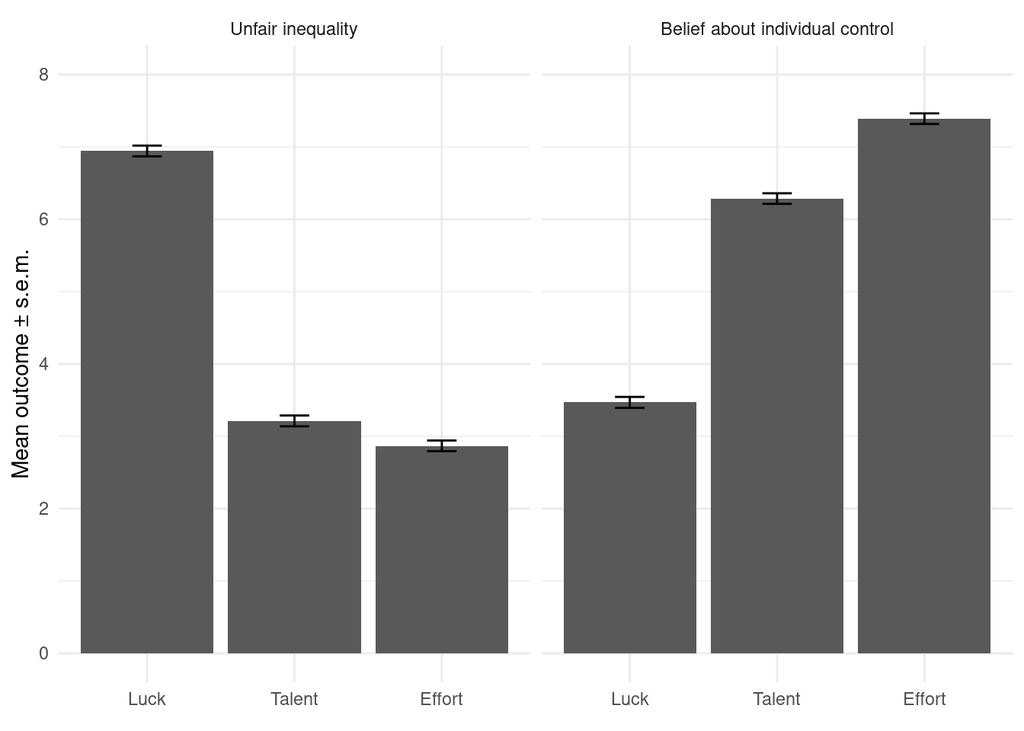

```r
long_attitudes(mmtalent) %>% survey_bars(numobs = FALSE, ylimits = c(0,8))
```

```r
ggsave(here::here("graphs","attitudes_beliefs.pdf"), width = 16, height =10, units = "cm")
```

And the corresponding histograms:

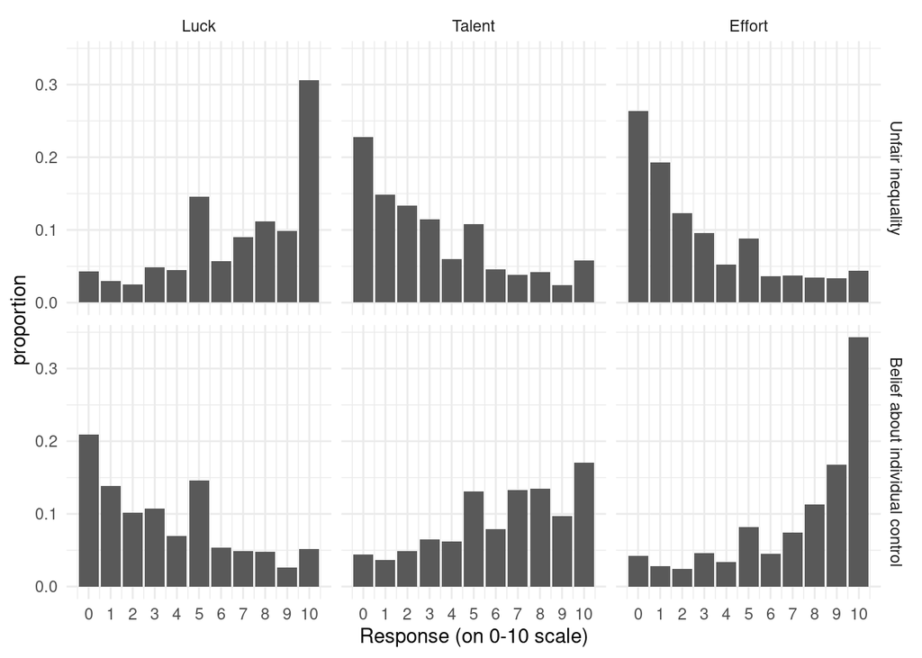

```r
long_attitudes(mmtalent) %>%
  group_by(outcometype, fo) %>%
  summarize(weighted.bars(value, wgt)) %>%
  ggplot(aes(x=v, y=proportion)) +
  geom_col() +
  theme_minimal() +
  labs(x = "Response (on 0-10 scale)") +
  scale_x_continuous(breaks=c(0,1,2,3,4,5,6,7,8,9,10)) +
  facet_grid(outcometype ~ fo)
```

```r
ggsave(here::here("graphs","attitude_histograms.pdf"), width = 16, height = 10, units = "cm")
```

# Subgroups

First for the division of all data into binary groups:

[figure not shown]

```r
long_attitudes(mmtalent) %>%
  survey_bars_by_subgroup() %>%
  patchwork::wrap_plots() + plot_layout(ncol=2) + plot_annotation(tag_levels = "a")
```

```r
ggsave(here::here("graphs","attitudes_beliefs_by_subgroups.pdf"), width = 30, height = 50, units="cm")
```

Now with all the $2^5$ combinations:

[figure not shown]

```r
long_attitudes(mmtalent) %>%
  survey_bars_by_subgroup_cross() %>%
  patchwork::wrap_plots() + plot_layout(ncol=4) + plot_annotation(tag_levels = "1")
```

```r
ggsave(here::here("graphs","attitudes_beliefs_by_subgroups_cross.pdf"), width = 30, height = 50, units="cm")
```

Now, interacting with political position:

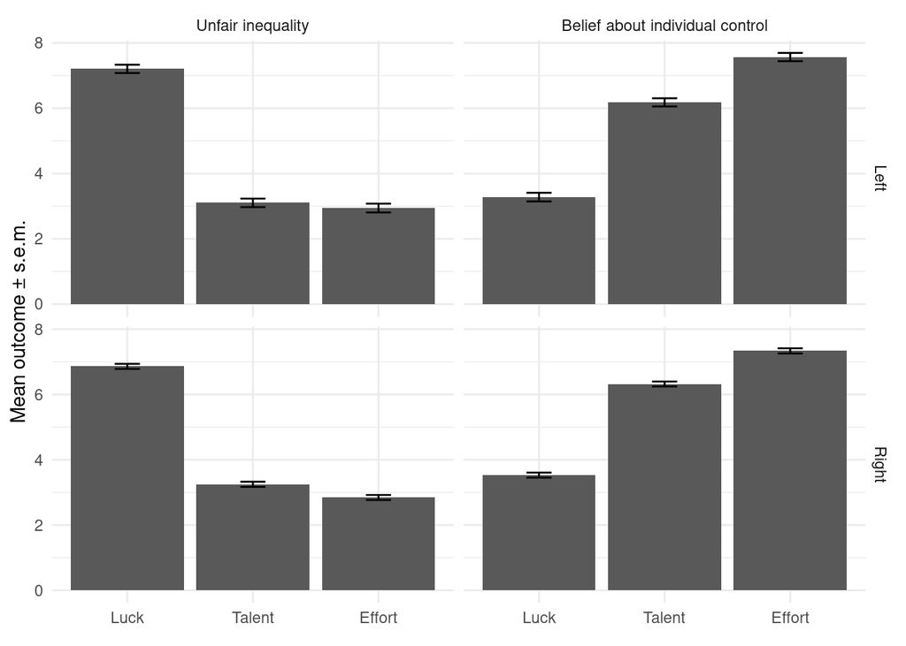

```r
long_attitudes(mmtalent) %>%
  mutate(left_description = c("Right", "Left")[left+1]) %>%
  group_by(outcometype, left_description, fo, outcome) %>% summarize(m = weighted.mean(value, wgt), se = weighted.sd(value,wgt)/sqrt(n()))  %>%
  ggplot(aes(x=fo, y=m)) +
  geom_bar(stat="identity") + facet_grid(left_description ~ outcometype) +
  geom_errorbar(aes(ymin=m-se, ymax=m+se), width=0.2) +
  labs(x=element_blank(), y="Mean outcome \u00B1 s.e.m.") +
  theme_minimal()
```

```r
ggsave(here::here("graphs","attitudes_beliefs_pol.pdf"))
```

# Regression table

We want to put attitudes on the left hand side and try to explain it by the type of attitude and the perception of control in the situation.

Now, we need to turn the data around a bit first:

```r
subjectives_dt <- long_attitudes(mmtalent) %>%
  subjectives()
subjectives_dt %>% sample_n(3)
```

```
## # A tibble: 3 x 16
##      id fo    treatment  gender   age left  high_income income_category high_edu
##   <int> <fct> <fct>      <chr>  <dbl> <lgl> <lgl>       <chr>           <lgl>
## 1  1704 Luck  ExPostPer… male      70 FALSE FALSE       30k- 59 999     TRUE
## 2  1039 Luck  ExAnteImp… female    29 FALSE FALSE       30k- 59 999     TRUE
## 3  1823 Luck  ExAnteImp… male      49 FALSE FALSE       30k- 59 999     FALSE
## # … with 7 more variables: edu_category <chr>, wgt <dbl>,
## #   Unfair inequality <dbl>, Belief about individual control <dbl>, Luck <dbl>,
## #   Effort <dbl>, Talent <dbl>
```

Now, it should be possible to run the regression
$$A_{i,t} = \beta_0 + \beta_1 B_{i,t} + \beta_2 X_i + \phi_t + \epsilon_{i,t},$$
where $i$ index the individual, and $t\in\{ \mathrm{effort}, \mathrm{talent}, \mathrm{luck}\}$, $A_{i,t}\in[0,10]$ is the fairness attitude, $B_{i,t}\in[0,10]$ is the control belief, $X_i$ is a set of individual controls, and $\phi_t$ is a set of fixed effect for each factor.

```r
survey_regressions_list <- survey_regressions(subjectives_dt)
subjectives_dt %>% janitor::clean_names() %>% haven::write_dta("subjectives.dta")
survey_names <- c('Talent'='Talent (d)',
                  'Effort'='Effort (d)',
                   '`Belief about individual control`'='Belief about control (0-10)',
                  'Talent:`Belief about individual control`' = 'Talent x Belief about control',
                  'Effort:`Belief about individual control`' = 'Effort x Belief about control',
                  'age' = 'Age (years)',
                  'leftTRUE' = 'Left (d)',
                  'high_incomeTRUE' = 'High income (d)',
                  'high_eduTRUE' = 'High education (d)',
                  'as.factor(gender)male' = 'Male (d)',
                  'treatmentExAntePersonal' = "Treatment: Ex Ante Personal (d)",
                  'treatmentExPostImpersonal'   = "Treatment: Ex Post Impersonal (d)",
                  'treatmentExPostPersonal' = "Treatment: Ex Post Personal (d)",
                  '(Intercept)'='(Intercept)')
```

Talent (d)

-3.731***

-3.377***

-3.372***

-3.480***

-3.395***

(0.107)

(0.109)

(0.206)

(0.208)

(0.109)

Effort (d)

-4.076***

-3.583***

-3.267***

-3.456***

-3.609***

(0.111)

(0.121)

(0.225)

(0.232)

(0.122)

Belief about control (0-10)

-0.126***

-0.104***

-0.115***

-0.119***

(0.019)

(0.027)

(0.028)

(0.019)

Talent x Belief about control

-0.011

0.012

(0.035)

(0.035)

Effort x Belief about control

-0.054

-0.023

(0.033)

(0.035)

Age (years)

-0.014***

-0.014***

(0.003)

(0.003)

Left (d)

0.125

0.122

(0.115)

(0.115)

High income (d)

-0.145

-0.145

(0.109)

(0.109)

High education (d)

-0.182*

-0.183*

(0.110)

(0.110)

Male (d)

0.166

0.169*

(0.101)

(0.100)

(Intercept)

6.944***

7.381***

7.305***

8.003***

8.023***

(0.075)

(0.102)

(0.121)

(0.192)

(0.164)

Num.Obs.

6003

6003

6003

6003

6003

R2

0.277

0.288

0.289

0.295

0.294

* p < 0.1, ** p < 0.05, *** p < 0.01

# Are there treatment effects on attitudes?

The survey came after the experiment. Are there any treatment effect on the survey outcomes?

The simplest is to repeat the main regression table with dummies for treatment. We test for joint significance of the treatment dummies.

```r
surv_joint_tests <- c(car::linearHypothesis(survey_regressions_list$with_treatment[[1]],
                            c("treatmentExAntePersonal = 0",
                              "treatmentExPostPersonal = 0",
                              "treatmentExPostImpersonal = 0"))$`Pr(>Chisq)`[2],
                      car::linearHypothesis(survey_regressions_list$with_treatment[[2]],
                            c("treatmentExAntePersonal = 0",
                              "treatmentExPostPersonal = 0",
                              "treatmentExPostImpersonal = 0"))$`Pr(>Chisq)`[2],
                      car::linearHypothesis(survey_regressions_list$with_treatment[[3]],
                            c("treatmentExAntePersonal = 0",
                              "treatmentExPostPersonal = 0",
                              "treatmentExPostImpersonal = 0"))$`Pr(>Chisq)`[2],
                      car::linearHypothesis(survey_regressions_list$with_treatment[[4]],
                            c("treatmentExAntePersonal = 0",
                              "treatmentExPostPersonal = 0",
                              "treatmentExPostImpersonal = 0"))$`Pr(>Chisq)`[2],
                      car::linearHypothesis(survey_regressions_list$with_treatment[[5]],
                            c("treatmentExAntePersonal = 0",
                              "treatmentExPostPersonal = 0",
                              "treatmentExPostImpersonal = 0"))$`Pr(>Chisq)`[2])
surv_joint_tests_wrow <- tibble::tribble(~v, ~p1, ~p2, ~p3, ~p4, ~p5,
                        "Joint p-value on treatment dummies:",
                        sprintf("%4.3f", surv_joint_tests[1]),
                        sprintf("%4.3f", surv_joint_tests[2]),
                        sprintf("%4.3f", surv_joint_tests[3]),
                        sprintf("%4.3f", surv_joint_tests[4]),
                        sprintf("%4.3f", surv_joint_tests[5]))
```

Talent (d)

-3.731***

-3.380***

-3.392***

-3.503***

-3.399***

(0.107)

(0.109)

(0.207)

(0.209)

(0.109)

Effort (d)

-4.076***

-3.587***

-3.269***

-3.461***

-3.614***

(0.111)

(0.121)

(0.226)

(0.233)

(0.122)

Belief about control (0-10)

-0.125***

-0.104***

-0.116***

-0.118***

(0.019)

(0.027)

(0.028)

(0.019)

Talent x Belief about control

-0.007

0.015

(0.035)

(0.036)

Effort x Belief about control

-0.054

-0.022

(0.033)

(0.035)

Age (years)

-0.014***

-0.014***

(0.003)

(0.003)

Left (d)

0.121

0.118

(0.115)

(0.115)

High income (d)

-0.148

-0.148

(0.108)

(0.108)

High education (d)

-0.164

-0.166

(0.109)

(0.109)

Male (d)

0.170*

0.173*

(0.100)

(0.100)

Treatment: Ex Ante Personal (d)

-0.144

-0.129

-0.133

-0.152

-0.149

(0.139)

(0.142)

(0.141)

(0.139)

(0.139)

Treatment: Ex Post Impersonal (d)

-0.067

-0.065

-0.065

-0.052

-0.051

(0.137)

(0.139)

(0.139)

(0.139)

(0.139)

Treatment: Ex Post Personal (d)

0.277*

0.266*

0.265*

0.267*

0.267*

(0.141)

(0.144)

(0.144)

(0.144)

(0.144)

(Intercept)

6.925***

7.356***

7.286***

7.993***

8.006***

(0.112)

(0.133)

(0.149)

(0.211)

(0.186)

Num.Obs.

6003

6003

6003

6003

6003

R2

0.279

0.290

0.290

0.297

0.296

Joint p-value on treatment dummies:

0.020

0.039

0.037

0.027

0.028

* p < 0.1, ** p < 0.05, *** p < 0.01

We test for joint significance of the treatment effects for each of the 6 outcomes.

```r
A1 <- lm(luck_fair ~ treatment, data = mmtalent)
A1w <- car::linearHypothesis(A1, c("treatmentExAntePersonal = 0",
                          "treatmentExPostPersonal = 0",
                          "treatmentExPostImpersonal = 0"))
A2 <- lm(talent_fair ~ treatment, data = mmtalent)
A2w <- car::linearHypothesis(A2, c("treatmentExAntePersonal = 0",
                          "treatmentExPostPersonal = 0",
                          "treatmentExPostImpersonal = 0"))
A3 <- lm(effort_fair ~ treatment, data = mmtalent)
A3w <- car::linearHypothesis(A3, c("treatmentExAntePersonal = 0",
                          "treatmentExPostPersonal = 0",
                          "treatmentExPostImpersonal = 0"))
B1 <- lm(luck_control ~ treatment, data = mmtalent)
B1w <- car::linearHypothesis(B1, c("treatmentExAntePersonal = 0",
                          "treatmentExPostPersonal = 0",
                          "treatmentExPostImpersonal = 0"))
B2 <- lm(talent_control ~ treatment, data = mmtalent)
B2w <- car::linearHypothesis(B2, c("treatmentExAntePersonal = 0",
                          "treatmentExPostPersonal = 0",
                          "treatmentExPostImpersonal = 0"))
B3 <- lm(effort_control ~ treatment, data = mmtalent)
B3w <- car::linearHypothesis(B3, c("treatmentExAntePersonal = 0",
                          "treatmentExPostPersonal = 0",
                          "treatmentExPostImpersonal = 0"))

wrow <- tibble::tribble(~v, ~p1, ~p2, ~p3, ~p4, ~p5, ~p6,
                        "Joint p-value on treatment dummies:",
          sprintf("%4.3f", A1w$`Pr(>F)`[2]),
          sprintf("%4.3f", A2w$`Pr(>F)`[2]),
          sprintf("%4.3f", A3w$`Pr(>F)`[2]),
          sprintf("%4.3f", B1w$`Pr(>F)`[2]),
          sprintf("%4.3f", B2w$`Pr(>F)`[2]),
          sprintf("%4.3f", B3w$`Pr(>F)`[2]))

modelsummary::modelsummary(list("A.luck"=A1, "A.talent"=A2, "A.effort"=A3, "B.luck"=B1, "B.talent"=B2, "B.effort"=B3),
                           stars = c('*'=0.1, '**'=0.05, '***'=0.01),
                           gof_omit = "R2 Adj.|AIC|BIC|Log.Lik.|F",
                           add_rows = wrow) %>% kableExtra::add_header_above(c(" "=1, "Unfair inequality"=3, "Belief about individual control"=3))
```

|  | Unfair inequality A.luck | Unfair inequality A.talent | Unfair inequality A.effort | Belief about individual control B.luck | Belief about individual control B.talent | Belief about individual control B.effort |
| --- | --- | --- | --- | --- | --- | --- |
| (Intercept) | 6.710*** | 3.219*** | 2.905*** | 3.423*** | 6.095*** | 7.304*** |
|  | (0.137) | (0.136) | (0.134) | (0.135) | (0.133) | (0.138) |
| treatmentExAntePersonal | 0.132 | -0.076 | -0.121 | 0.120 | 0.259 | -0.110 |
|  | (0.193) | (0.192) | (0.189) | (0.190) | (0.188) | (0.195) |
| treatmentExPostImpersonal | 0.127 | -0.107 | -0.177 | -0.141 | 0.175 | 0.020 |
|  | (0.193) | (0.192) | (0.189) | (0.190) | (0.188) | (0.195) |
| treatmentExPostPersonal | 0.193 | 0.291 | 0.203 | 0.077 | -0.083 | -0.106 |
|  | (0.193) | (0.192) | (0.188) | (0.189) | (0.187) | (0.194) |
| Num.Obs. | 2001 | 2001 | 2001 | 2001 | 2001 | 2001 |
| R2 | 0.001 | 0.003 | 0.002 | 0.001 | 0.002 | 0.000 |
| Joint p-value on treatment dummies: | 0.787 | 0.145 | 0.187 | 0.534 | 0.242 | 0.861 |

* p < 0.1, ** p < 0.05, *** p < 0.01